# Final Exam

Nishant Khandhar A20581012

2025-12-09

# Instructions And Rules

1. Insert your name and A# in the author field above. You should only be taking this version of the exam if the *second to last digit* of your A# is *odd* (e.g. 1, 3, 5, 7, or 9).
2. You may use both textbooks as well as any course notes.
3. You may not consult ChatGPT or any other LLM-based chatbot. If you are caught violating this rule, you will be subject to failure on this exam and potentially the course.
4. You may not consult any other person (e.g. a classmate or your buddy who took this course last semester). If you are caught violating this rule, you will be subject to failure on this exam and potentially the course.
5. Please answer all of the questions below. You will need to write code in the appropriate code blocks. You will need to write text to answer the questions.
6. Please try to differentiate my questions from your answers in a clean and readable way. Please write in reasonably complete and comprehensible sentences.
7. You can add whatever libraries you need to the imports section below, but try to limit it to libraries that you’re actually using. I believe the ones listed there are sufficient, but you may use whatever you want.
8. Your Rmd file *must knit* at the end. You will be downgraded if this does not happen.

# Regression

```r
library(glmnet)
library(tidyverse)
```

```r
library(ggplot2)
library(ggrepel)
library(tree)
library(randomForest)
library(gam)
```

The goal of your final is to fit a regression model. The data is loaded below. (Make sure to put your data in the same path as this Rmd file.)

```r
data <- read.table("final_data_b.csv", sep=",", header=TRUE)
```

This is taken from a housing sales dataset. Here is a brief dictionary for the features:

`Lot.Frontage`: The length of the lot along the road or street `Lot.Area`: Total area of the lot `Neighborhood`: Neighborhood in which the property is located `Year.Built`: Year the structure was built `Garage.Type`: Garage location

```
   2Types   More than one type of garage
   Attchd   Attached to home
   Basment  Basement Garage
   BuiltIn  Built-In (Garage part of house - typically has room above garage)
   CarPort  Car Port
   Detchd   Detached from home
   NA   No Garage
```

`Garage.Cars`: Number of cars that fit in the garage

`Garage.Finish`: Interior finish of the garage

```
   Fin  Finished
   RFn  Rough Finished
   Unf  Unfinished
   NA   No Garage
```

`Paved.Drive`: Paved Drive (Ordinal): Paved driveway

```
   Y    Paved
   P    Partial Pavement
   N    Dirt/Gravel
```

`X1st.Flr.SF`: First floor square footage

`X2nd.Flr.SF`: Second floor square footage

`Full.Bath`: Number of full bathrooms

`Bedroom.AbvGr`: Number of bedrooms above ground

`SalePrice`: The most recent Sale price

Your goal will be to predict the sale price using the other features. You *must* fill in the code blocks given, but if you want to add extra plots or derive additional features, it is up to you to present the best model you can.

## Exploration

Below, show the number of missing values per column:

```r
missing_counts <- colSums(is.na(data))
missing_counts
```

```
##  Lot.Frontage      Lot.Area  Neighborhood    Year.Built   Garage.Type
##           171             0             0             0             0
## Garage.Finish   Garage.Cars   Paved.Drive     Full.Bath   X1st.Flr.SF
##             0             0             0             0             0
##   X2nd.Flr.SF Bedroom.AbvGr     SalePrice
##             0             0             0
```

Show frequency counts of the various categorical features below (you can decide which features count as categorical):

```r
# ---- freq_counts ----

tbl_neighborhood   <- table(data$Neighborhood)
tbl_garage_type    <- table(data$Garage.Type)
tbl_garage_finish  <- table(data$Garage.Finish)
tbl_paved_drive    <- table(data$Paved.Drive)

tbl_neighborhood
```

```
##
## Blmngtn  BrDale BrkSide ClearCr CollgCr Crawfor Edwards Gilbert  Greens GrnHill
##       6       8      38      15      85      33      63      66       3       2
##  IDOTRR MeadowV Mitchel   NAmes NoRidge NPkVill NridgHt  NWAmes OldTown  Sawyer
##      38      11      43     162      19       6      57      47      83      54
## SawyerW Somerst StoneBr   SWISU  Timber Veenker
##      37      63      22      12      25       2
```

```r
tbl_garage_type
```

```
##
##          2Types  Attchd Basment BuiltIn CarPort  Detchd
##      58      12     593      12      53       5     267
```

```r
tbl_garage_finish
```

```
##
##     Fin RFn Unf
##  58 261 263 418
```

```r
tbl_paved_drive
```

```
##
##   N   P   Y
##  82  19 899
```

Plot the numerical features (including sales price) below as histograms:

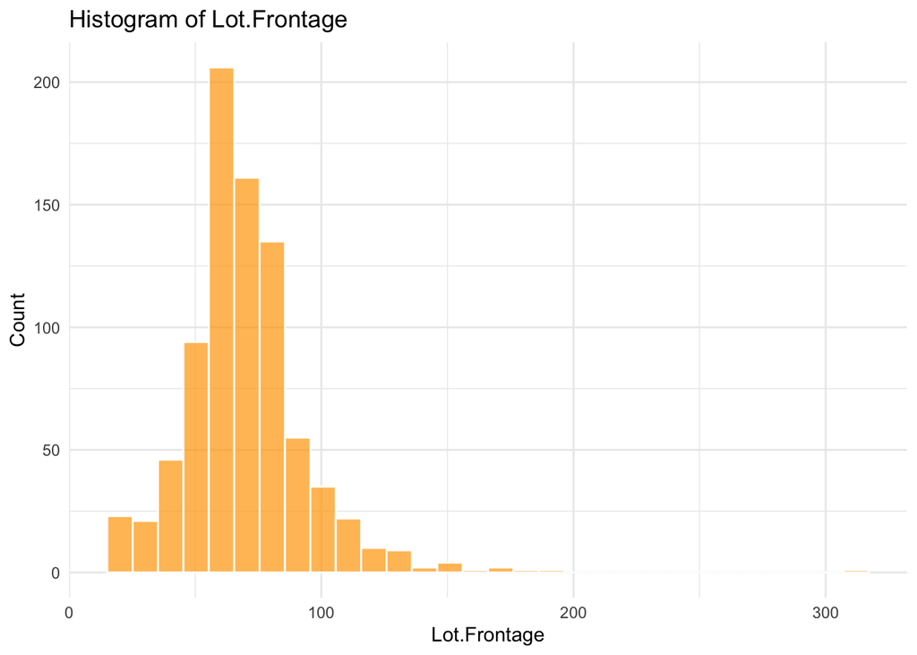

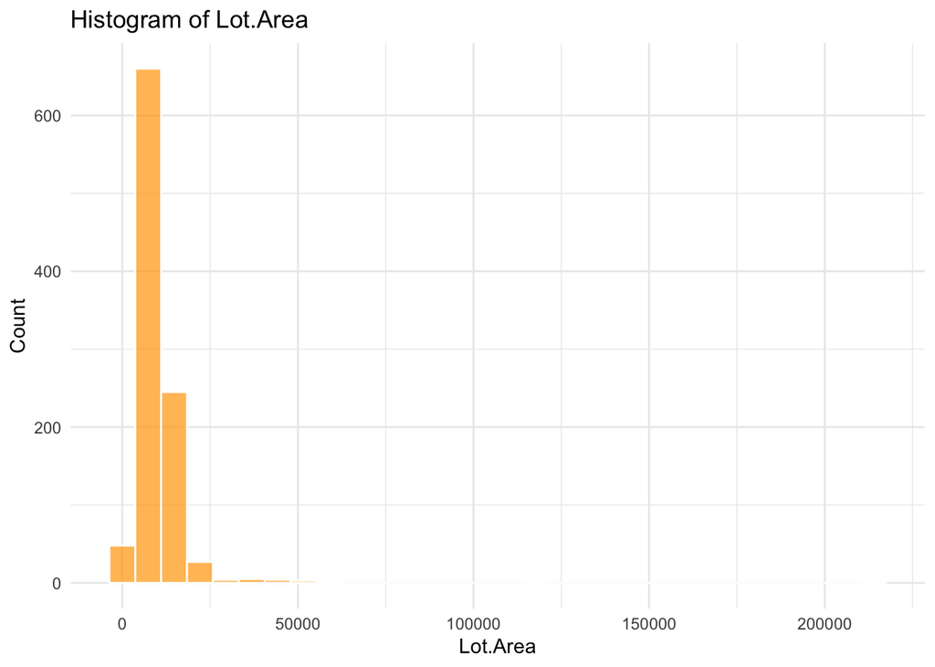

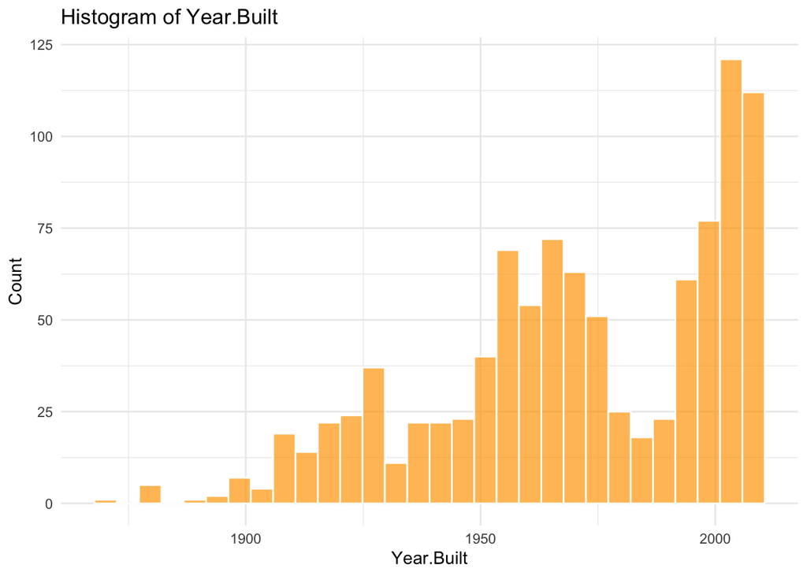

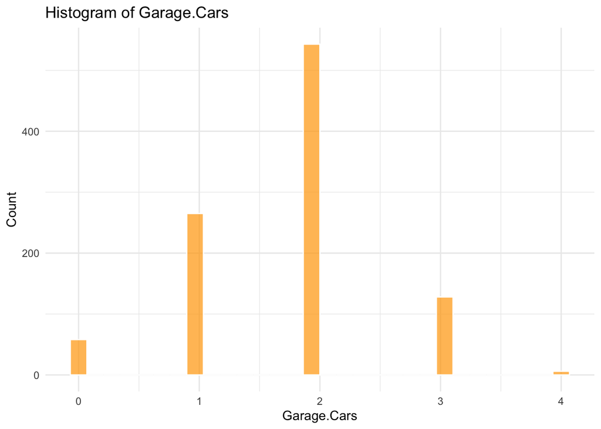

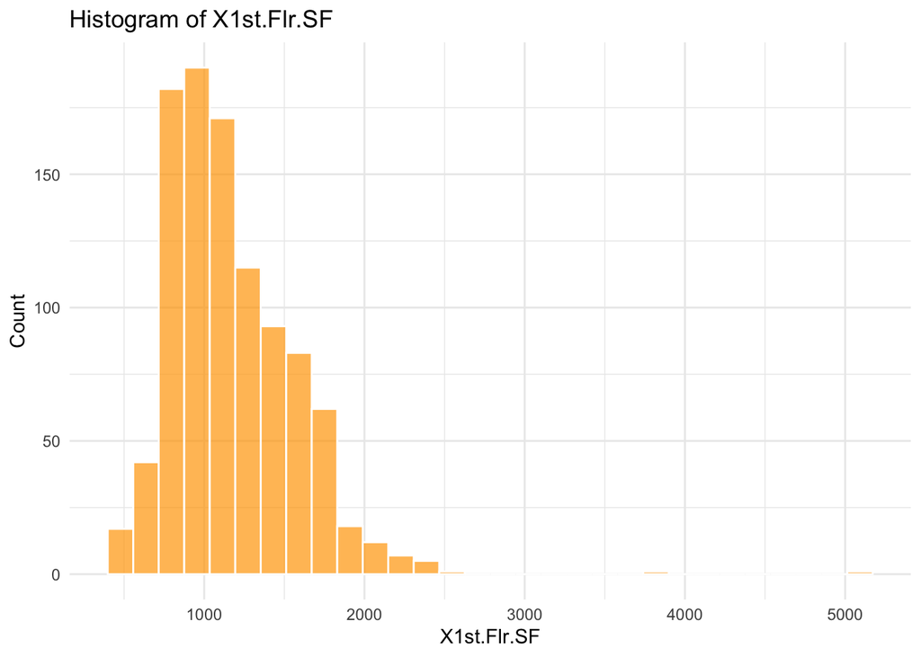

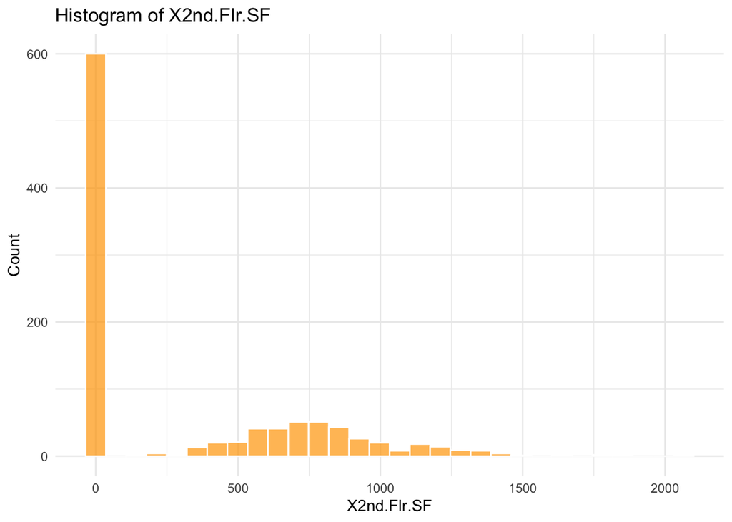

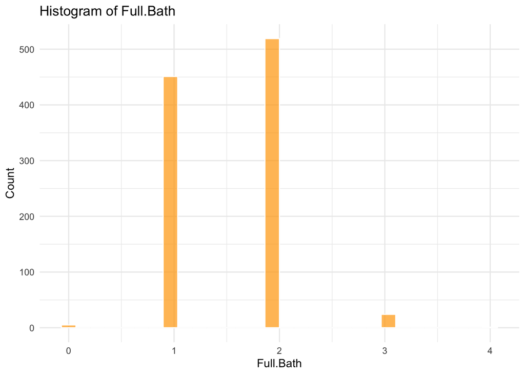

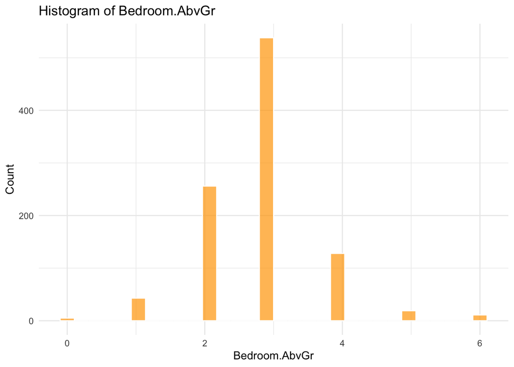

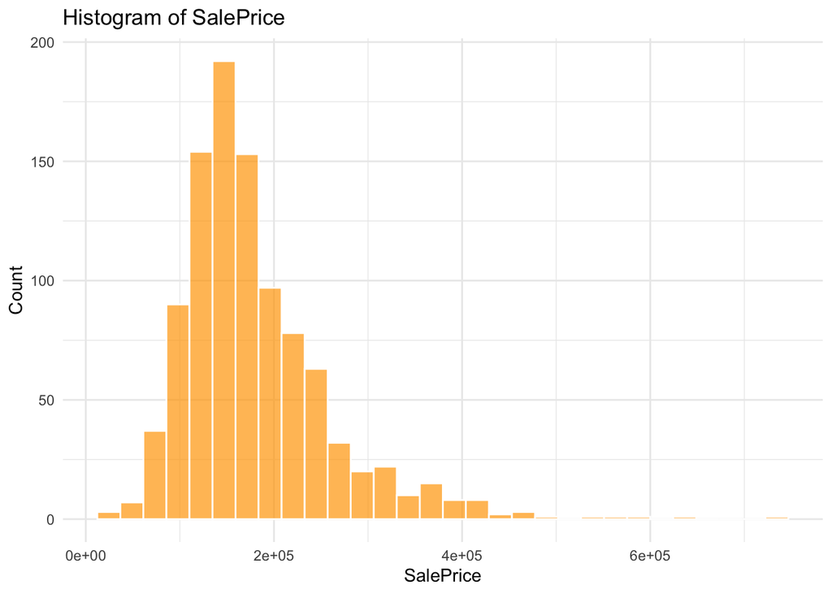

```r
# ---- plot_hist ----
library(ggplot2)

num_cols <- c(
  "Lot.Frontage", "Lot.Area", "Year.Built", "Garage.Cars",
  "X1st.Flr.SF", "X2nd.Flr.SF", "Full.Bath",
  "Bedroom.AbvGr", "SalePrice"
)

for (col in num_cols) {
  plt <- ggplot(data, aes_string(x = col)) +
    geom_histogram(bins = 30, fill = "orange", color = "white", alpha = 0.7) +
    labs(title = paste("Histogram of", col), x = col, y = "Count") +
    theme_minimal()

  print(plt)
}
```

Provide any other plots or exploratory analysis you think will be enlightening below:

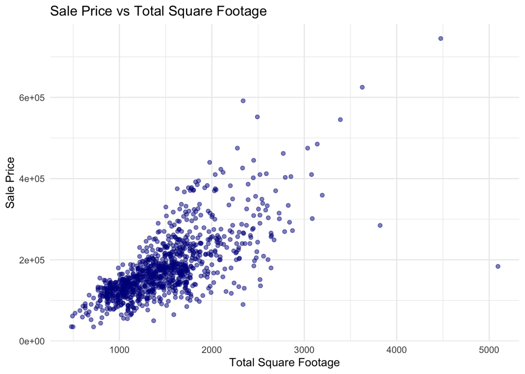

```r
# ---- other_plots ----

# Total square footage
data$TotalSF <- data$X1st.Flr.SF + data$X2nd.Flr.SF

# SalePrice vs Total SF
ggplot(data, aes(x = TotalSF, y = SalePrice)) +
  geom_point(alpha = 0.5, color = "darkblue") +
  labs(
    title = "Sale Price vs Total Square Footage",
    x = "Total Square Footage",
    y = "Sale Price"
  ) +
  theme_minimal()
```

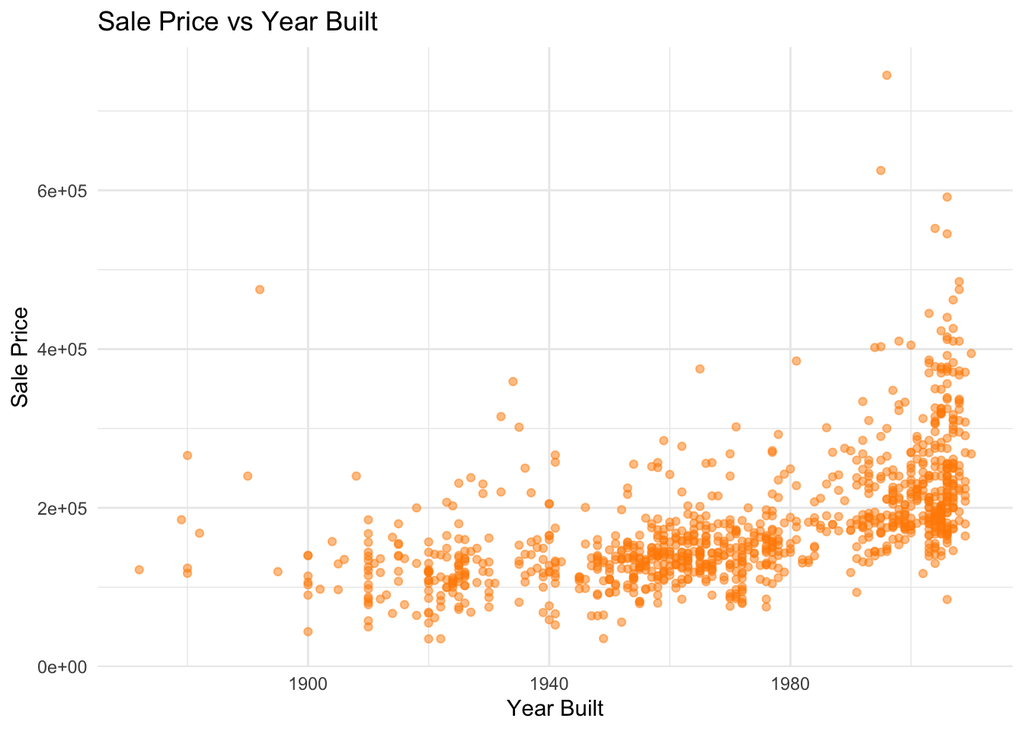

```r
# SalePrice vs Year Built
ggplot(data, aes(x = Year.Built, y = SalePrice)) +
  geom_point(alpha = 0.5, color = "darkorange") +
  labs(
    title = "Sale Price vs Year Built",
    x = "Year Built",
    y = "Sale Price"
  ) +
  theme_minimal()
```

```r
# ---- other_analysis ----

library(reshape2)
```

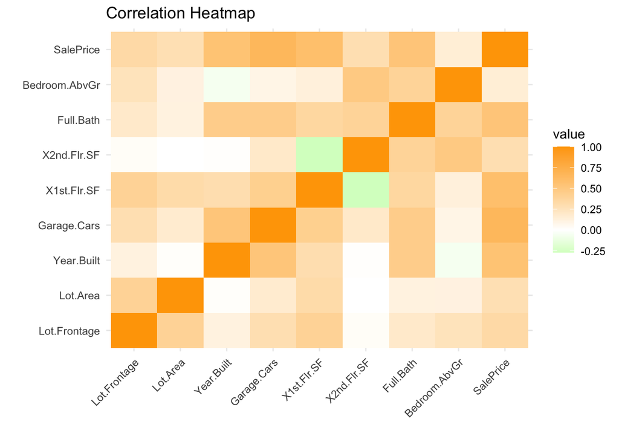

```r
num_df  <- data[, num_cols]
corrmat <- cor(num_df, use = "pairwise.complete.obs")

melted_corr <- melt(corrmat)

ggplot(melted_corr, aes(Var1, Var2, fill = value)) +
  geom_tile() +
  scale_fill_gradient2(low = "green", high = "orange", mid = "white") +
  labs(title = "Correlation Heatmap", x = "", y = "") +
  theme_minimal() +
  theme(axis.text.x = element_text(angle = 45, hjust = 1))
```

Can you find some outlying behavior? Should you eliminate these or keep them?

### Answer

A few properties with unusually large lot areas, very high total square footage, or unusually high sale prices are displayed in the scatter plots and histograms. Clearly, these points differ from the majority of the information.

But unless these observations are the result of data entry errors, they are not noise but rather real high-value homes. The model would be distorted if expensive homes were excluded because housing prices naturally vary widely.

Because they represent actual fluctuations in the housing market and could enhance the model’s capacity to forecast upscale properties, these outliers ought to be retained.

## Feature Transformations

You need to decide what to do with the missing values in `Lot.Frontage`. Include code below to handle these:

```r
# ---- handle_missings_frontage ----
library(dplyr)

overall_med_frontage <- median(data$Lot.Frontage, na.rm = TRUE)

data <- data %>%
  group_by(Neighborhood) %>%
  mutate(
    Lot.Frontage = ifelse(
      is.na(Lot.Frontage),
      ifelse(
        all(is.na(Lot.Frontage)),
        overall_med_frontage,
        median(Lot.Frontage, na.rm = TRUE)
      ),
      Lot.Frontage
    )
  ) %>%
  ungroup()
```

You should add a column to indicate if there is no garage (hint: the `Garage` features take the empty string value when the value is missing):

```r
# ---- no_garage ----
data <- data %>%
  mutate(
    NoGarage = as.integer(is.na(Garage.Type) | Garage.Type == "")
  )
```

You may want a feature indicating the total square footage of the house (combined 1st and 2nd floor):

```r
# ---- square_feet ----
data <- data %>%
  mutate(TotalSF = rowSums(across(c(X1st.Flr.SF, X2nd.Flr.SF))))
```

If there are any other transformations you would like to explore, you may place these below:

## GAMs

(See, for example, the Chapter 7 lab.)

Split your data into a training set (800 samples) and test (200 samples).

```r
# ---- train_test_split ----
set.seed(123)

train_idx  <- sample(seq_len(nrow(data)), size = 800)

train_data <- data[train_idx, ]
test_data  <- data[-train_idx, ]
```

Fit a basic linear regression on the training data:

```r
# ---- basic_lm ----

basic_lm <- lm(
  SalePrice ~ TotalSF + Year.Built + Garage.Cars + Full.Bath +
    Bedroom.AbvGr + Lot.Area + Lot.Frontage +
    Neighborhood + Garage.Type + Paved.Drive + NoGarage,
  data = train_data
)

summary(basic_lm)
```

```
##
## Call:
## lm(formula = SalePrice ~ TotalSF + Year.Built + Garage.Cars +
##     Full.Bath + Bedroom.AbvGr + Lot.Area + Lot.Frontage + Neighborhood +
##     Garage.Type + Paved.Drive + NoGarage, data = train_data)
##
## Residuals:
##     Min      1Q  Median      3Q     Max
## -323351  -17076   -1035   16151  239877
##
## Coefficients: (1 not defined because of singularities)
##                       Estimate Std. Error t value Pr(>|t|)
## (Intercept)         -1.203e+06  2.132e+05  -5.645 2.34e-08 ***
## TotalSF              7.157e+01  4.569e+00  15.667  < 2e-16 ***
## Year.Built           6.253e+02  1.072e+02   5.835 7.97e-09 ***
## Garage.Cars          1.887e+04  3.173e+03   5.946 4.20e-09 ***
## Full.Bath            7.989e+02  3.641e+03   0.219 0.826374
## Bedroom.AbvGr       -9.435e+03  2.101e+03  -4.490 8.23e-06 ***
## Lot.Area             9.506e-01  1.522e-01   6.246 7.00e-10 ***
## Lot.Frontage         1.308e+02  7.222e+01   1.811 0.070555 .
## NeighborhoodBrDale   4.525e+03  2.178e+04   0.208 0.835456
## NeighborhoodBrkSide  3.429e+04  1.931e+04   1.776 0.076094 .
## NeighborhoodClearCr  2.621e+04  2.029e+04   1.292 0.196753
## NeighborhoodCollgCr  2.396e+04  1.740e+04   1.377 0.169033
## NeighborhoodCrawfor  7.042e+04  1.888e+04   3.730 0.000206 ***
## NeighborhoodEdwards  5.608e+03  1.816e+04   0.309 0.757517
## NeighborhoodGilbert  3.957e+03  1.762e+04   0.225 0.822368
## NeighborhoodGreens   1.949e+04  4.057e+04   0.480 0.631046
## NeighborhoodGrnHill  1.230e+05  3.122e+04   3.942 8.84e-05 ***
## NeighborhoodIDOTRR   1.922e+04  1.967e+04   0.977 0.328707
## NeighborhoodMeadowV -1.215e+04  2.174e+04  -0.559 0.576383
## NeighborhoodMitchel  1.285e+04  1.801e+04   0.714 0.475637
## NeighborhoodNAmes    1.876e+04  1.773e+04   1.058 0.290173
## NeighborhoodNoRidge  9.172e+04  1.973e+04   4.648 3.95e-06 ***
## NeighborhoodNPkVill  7.785e+03  2.500e+04   0.311 0.755552
## NeighborhoodNridgHt  8.647e+04  1.762e+04   4.908 1.12e-06 ***
## NeighborhoodNWAmes   1.735e+04  1.815e+04   0.956 0.339385
## NeighborhoodOldTown  2.737e+04  1.906e+04   1.436 0.151467
## NeighborhoodSawyer   1.900e+04  1.836e+04   1.035 0.301045
## NeighborhoodSawyerW  1.173e+04  1.806e+04   0.650 0.516031
## NeighborhoodSomerst  3.600e+04  1.742e+04   2.067 0.039092 *
## NeighborhoodStoneBr  9.122e+04  1.859e+04   4.907 1.13e-06 ***
## NeighborhoodSWISU    3.516e+04  2.203e+04   1.596 0.110903
## NeighborhoodTimber   4.130e+04  1.882e+04   2.194 0.028517 *
## NeighborhoodVeenker  9.114e+04  3.160e+04   2.884 0.004041 **
## Garage.Type2Types   -5.474e+04  1.878e+04  -2.914 0.003671 **
## Garage.TypeAttchd   -1.453e+04  8.235e+03  -1.765 0.077969 .
## Garage.TypeBasment  -3.581e+04  1.465e+04  -2.444 0.014757 *
## Garage.TypeBuiltIn  -1.114e+04  1.020e+04  -1.092 0.274966
## Garage.TypeCarPort  -6.138e+04  2.362e+04  -2.598 0.009549 **
## Garage.TypeDetchd   -2.425e+04  8.284e+03  -2.927 0.003524 **
## Paved.DriveP         1.187e+04  1.049e+04   1.131 0.258405
## Paved.DriveY         5.689e+03  6.219e+03   0.915 0.360624
## NoGarage                    NA         NA      NA       NA
## ---
## Signif. codes:  0 '***' 0.001 '**' 0.01 '*' 0.05 '.' 0.1 ' ' 1
##
## Residual standard error: 36850 on 759 degrees of freedom
## Multiple R-squared:  0.8052, Adjusted R-squared:  0.795
## F-statistic: 78.46 on 40 and 759 DF,  p-value: < 2.2e-16
```

Using the output above to select features, fit a couple of reasonable GAMs that might be good candidates.

```r
library(mgcv)
# GAM 1 — smooth TotalSF + smooth Year.Built + basic categorical effects
gam1 <- gam(SalePrice ~ s(TotalSF) + s(Year.Built) +
              Garage.Cars + Full.Bath + Neighborhood,
            data = train_data)

# GAM 2 — smooth TotalSF + smooth Lot.Area + Garage categorical + Neighborhood
gam2 <- gam(SalePrice ~ s(TotalSF) + s(Lot.Area) +
              Garage.Type + Neighborhood,
            data = train_data)

# GAM 3 — more flexible: smooths on TotalSF + Year.Built + Lot.Frontage
gam3 <- gam(SalePrice ~ s(TotalSF) + s(Year.Built) + s(Lot.Frontage) +
              Neighborhood + NoGarage,
            data = train_data)

summary(gam1)
```

```
##
## Family: gaussian
## Link function: identity
##
## Formula:
## SalePrice ~ s(TotalSF) + s(Year.Built) + Garage.Cars + Full.Bath +
##     Neighborhood
##
## Parametric coefficients:
##                     Estimate Std. Error t value Pr(>|t|)
## (Intercept)           133817      18340   7.297 7.46e-13 ***
## Garage.Cars            15870       2427   6.539 1.14e-10 ***
## Full.Bath              -9290       3561  -2.609 0.009267 **
## NeighborhoodBrDale     -2758      21483  -0.128 0.897873
## NeighborhoodBrkSide    31299      18893   1.657 0.098010 .
## NeighborhoodClearCr    66367      19715   3.366 0.000800 ***
## NeighborhoodCollgCr    26358      16748   1.574 0.115948
## NeighborhoodCrawfor    72070      18388   3.919 9.68e-05 ***
## NeighborhoodEdwards    14887      17720   0.840 0.401087
## NeighborhoodGilbert    11308      16949   0.667 0.504846
## NeighborhoodGreens     43760      39732   1.101 0.271086
## NeighborhoodGrnHill   147520      30365   4.858 1.44e-06 ***
## NeighborhoodIDOTRR     19555      19112   1.023 0.306536
## NeighborhoodMeadowV    -9775      21632  -0.452 0.651469
## NeighborhoodMitchel    26647      17635   1.511 0.131206
## NeighborhoodNAmes      31264      17503   1.786 0.074466 .
## NeighborhoodNoRidge    85165      19792   4.303 1.91e-05 ***
## NeighborhoodNPkVill    23397      24813   0.943 0.346010
## NeighborhoodNridgHt    87831      16925   5.190 2.71e-07 ***
## NeighborhoodNWAmes     37870      17992   2.105 0.035638 *
## NeighborhoodOldTown    21878      18411   1.188 0.235081
## NeighborhoodSawyer     25581      18033   1.419 0.156439
## NeighborhoodSawyerW    21355      17674   1.208 0.227319
## NeighborhoodSomerst    33774      16797   2.011 0.044717 *
## NeighborhoodStoneBr    95271      18146   5.250 1.98e-07 ***
## NeighborhoodSWISU      28232      21446   1.316 0.188426
## NeighborhoodTimber     62384      17920   3.481 0.000528 ***
## NeighborhoodVeenker   139020      30749   4.521 7.14e-06 ***
## ---
## Signif. codes:  0 '***' 0.001 '**' 0.01 '*' 0.05 '.' 0.1 ' ' 1
##
## Approximate significance of smooth terms:
##                 edf Ref.df     F p-value
## s(TotalSF)    8.674  8.969 52.89  <2e-16 ***
## s(Year.Built) 5.519  6.705 14.87  <2e-16 ***
## ---
## Signif. codes:  0 '***' 0.001 '**' 0.01 '*' 0.05 '.' 0.1 ' ' 1
##
## R-sq.(adj) =  0.808   Deviance explained = 81.8%
## GCV = 1.3456e+09  Scale est. = 1.2746e+09  n = 800
```

```r
summary(gam2)
```

```
##
## Family: gaussian
## Link function: identity
##
## Formula:
## SalePrice ~ s(TotalSF) + s(Lot.Area) + Garage.Type + Neighborhood
##
## Parametric coefficients:
##                     Estimate Std. Error t value Pr(>|t|)
## (Intercept)         186217.1    18775.1   9.918  < 2e-16 ***
## Garage.Type2Types   -13715.6    18066.7  -0.759 0.447992
## Garage.TypeAttchd    27708.3     6657.5   4.162 3.52e-05 ***
## Garage.TypeBasment    3472.3    14057.5   0.247 0.804970
## Garage.TypeBuiltIn   22157.9     9190.6   2.411 0.016150 *
## Garage.TypeCarPort   -6993.4    23131.0  -0.302 0.762476
## Garage.TypeDetchd     9424.2     6410.0   1.470 0.141914
## NeighborhoodBrDale  -47529.2    21849.0  -2.175 0.029914 *
## NeighborhoodBrkSide -46367.8    18781.2  -2.469 0.013776 *
## NeighborhoodClearCr -35082.0    20892.4  -1.679 0.093532 .
## NeighborhoodCollgCr -12618.6    18250.6  -0.691 0.489522
## NeighborhoodCrawfor    816.6    18938.7   0.043 0.965620
## NeighborhoodEdwards -63573.3    18631.2  -3.412 0.000679 ***
## NeighborhoodGilbert -29218.1    18452.4  -1.583 0.113742
## NeighborhoodGreens   -2348.4    41110.0  -0.057 0.954461
## NeighborhoodGrnHill  81159.6    31832.8   2.550 0.010983 *
## NeighborhoodIDOTRR  -66363.3    19594.3  -3.387 0.000744 ***
## NeighborhoodMeadowV -63059.1    21798.3  -2.893 0.003928 **
## NeighborhoodMitchel -28477.8    18866.2  -1.509 0.131599
## NeighborhoodNAmes   -50082.5    18112.3  -2.765 0.005829 **
## NeighborhoodNoRidge  48492.5    20824.1   2.329 0.020140 *
## NeighborhoodNPkVill -33886.7    25248.9  -1.342 0.179965
## NeighborhoodNridgHt  68940.8    18383.0   3.750 0.000190 ***
## NeighborhoodNWAmes  -38879.9    18834.6  -2.064 0.039332 *
## NeighborhoodOldTown -59881.9    18412.9  -3.252 0.001196 **
## NeighborhoodSawyer  -52329.0    18856.2  -2.775 0.005654 **
## NeighborhoodSawyerW -24446.0    18829.5  -1.298 0.194589
## NeighborhoodSomerst  18824.9    17970.2   1.048 0.295176
## NeighborhoodStoneBr  68435.4    19273.0   3.551 0.000408 ***
## NeighborhoodSWISU   -57362.4    21501.5  -2.668 0.007798 **
## NeighborhoodTimber   17213.8    19651.1   0.876 0.381325
## NeighborhoodVeenker  74732.3    32850.5   2.275 0.023191 *
## ---
## Signif. codes:  0 '***' 0.001 '**' 0.01 '*' 0.05 '.' 0.1 ' ' 1
##
## Approximate significance of smooth terms:
##               edf Ref.df      F p-value
## s(TotalSF)  8.332  8.877 48.213  <2e-16 ***
## s(Lot.Area) 5.929  6.901  8.726  <2e-16 ***
## ---
## Signif. codes:  0 '***' 0.001 '**' 0.01 '*' 0.05 '.' 0.1 ' ' 1
##
## R-sq.(adj) =  0.789   Deviance explained = 80.1%
## GCV = 1.4848e+09  Scale est. = 1.3989e+09  n = 800
```

```r
summary(gam3)
```

```
##
## Family: gaussian
## Link function: identity
##
## Formula:
## SalePrice ~ s(TotalSF) + s(Year.Built) + s(Lot.Frontage) + Neighborhood +
##     NoGarage
##
## Parametric coefficients:
##                     Estimate Std. Error t value Pr(>|t|)
## (Intercept)           152602      16862   9.050  < 2e-16 ***
## NeighborhoodBrDale     23069      26397   0.874 0.382440
## NeighborhoodBrkSide    26741      19012   1.407 0.159986
## NeighborhoodClearCr    50614      20321   2.491 0.012963 *
## NeighborhoodCollgCr    18407      17227   1.068 0.285647
## NeighborhoodCrawfor    69876      18570   3.763 0.000181 ***
## NeighborhoodEdwards    11798      17993   0.656 0.512211
## NeighborhoodGilbert    -3117      17572  -0.177 0.859249
## NeighborhoodGreens     58715      39841   1.474 0.140968
## NeighborhoodGrnHill   127339      30664   4.153 3.66e-05 ***
## NeighborhoodIDOTRR     14371      19361   0.742 0.458161
## NeighborhoodMeadowV     8941      23918   0.374 0.708650
## NeighborhoodMitchel    23874      17996   1.327 0.185031
## NeighborhoodNAmes      30046      17953   1.674 0.094630 .
## NeighborhoodNoRidge    84203      20160   4.177 3.30e-05 ***
## NeighborhoodNPkVill    41336      26694   1.549 0.121918
## NeighborhoodNridgHt    80633      17397   4.635 4.21e-06 ***
## NeighborhoodNWAmes     34788      18504   1.880 0.060495 .
## NeighborhoodOldTown    16282      18666   0.872 0.383329
## NeighborhoodSawyer     22380      18477   1.211 0.226180
## NeighborhoodSawyerW    14883      18092   0.823 0.410957
## NeighborhoodSomerst    29170      17199   1.696 0.090295 .
## NeighborhoodStoneBr    95873      18297   5.240 2.09e-07 ***
## NeighborhoodSWISU      20607      21595   0.954 0.340265
## NeighborhoodTimber     53484      18489   2.893 0.003929 **
## NeighborhoodVeenker   160428      30470   5.265 1.83e-07 ***
## NoGarage              -22696       6052  -3.750 0.000190 ***
## ---
## Signif. codes:  0 '***' 0.001 '**' 0.01 '*' 0.05 '.' 0.1 ' ' 1
##
## Approximate significance of smooth terms:
##                   edf Ref.df      F  p-value
## s(TotalSF)      8.395  8.897 64.684  < 2e-16 ***
## s(Year.Built)   5.931  7.112 19.482  < 2e-16 ***
## s(Lot.Frontage) 8.481  8.912  4.724 7.18e-06 ***
## ---
## Signif. codes:  0 '***' 0.001 '**' 0.01 '*' 0.05 '.' 0.1 ' ' 1
##
## R-sq.(adj) =  0.807   Deviance explained = 81.9%
## GCV = 1.3642e+09  Scale est. = 1.2793e+09  n = 800
```

Use an ANOVA test to select your best model.

```r
anova(gam1, gam2, gam3, test = "F")
```

```
## Analysis of Deviance Table
##
## Model 1: SalePrice ~ s(TotalSF) + s(Year.Built) + Garage.Cars + Full.Bath +
##     Neighborhood
## Model 2: SalePrice ~ s(TotalSF) + s(Lot.Area) + Garage.Type + Neighborhood
## Model 3: SalePrice ~ s(TotalSF) + s(Year.Built) + s(Lot.Frontage) + Neighborhood +
##     NoGarage
##   Resid. Df Resid. Dev     Df    Deviance      F    Pr(>F)
## 1    756.33 9.6592e+11
## 2    752.22 1.0544e+12 4.1044 -8.8496e+10
## 3    748.08 9.5971e+11 4.1419  9.4703e+10 17.873 2.029e-14 ***
## ---
## Signif. codes:  0 '***' 0.001 '**' 0.01 '*' 0.05 '.' 0.1 ' ' 1
```

Compute the MSE of your best model against the test set you defined above:

```r
# Predict on test set
test_pred <- predict(gam3, newdata = test_data)   # replace gam3 with your best model

# Compute mean squared error
mse <- mean((test_data$SalePrice - test_pred)^2)

mse
```

```
## [1] 1259709406
```

## Log-Transforms

Create a new response variable by log-transforming the `SalePrice` and repeat the steps above. Remember to compute the MSE of `SalePrice` at the end *not* of `Log.SalePrice`! You should transform your predictions back to the original scale before doing the MSE calculation.

```r
# Create new response variable
data <- data %>%
  mutate(LogSalePrice = log(SalePrice))

# Recreate the same training/test split structure (same seed)
set.seed(123)
train_idx <- sample(1:nrow(data), 800)
train_log <- data[train_idx, ]
test_log  <- data[-train_idx, ]
```

```r
library(mgcv)

# Basic LM on log-price
lm_log <- lm(LogSalePrice ~ TotalSF + Year.Built + Garage.Cars + Full.Bath +
               Bedroom.AbvGr + Lot.Area + Lot.Frontage + Neighborhood +
               Garage.Type + Paved.Drive + NoGarage,
             data = train_log)

summary(lm_log)
```

```
##
## Call:
## lm(formula = LogSalePrice ~ TotalSF + Year.Built + Garage.Cars +
##     Full.Bath + Bedroom.AbvGr + Lot.Area + Lot.Frontage + Neighborhood +
##     Garage.Type + Paved.Drive + NoGarage, data = train_log)
##
## Residuals:
##      Min       1Q   Median       3Q      Max
## -1.37083 -0.08666  0.00986  0.09293  0.51372
##
## Coefficients: (1 not defined because of singularities)
##                       Estimate Std. Error t value Pr(>|t|)
## (Intercept)          5.076e+00  1.020e+00   4.976 8.03e-07 ***
## TotalSF              3.392e-04  2.186e-05  15.514  < 2e-16 ***
## Year.Built           3.096e-03  5.128e-04   6.037 2.46e-09 ***
## Garage.Cars          9.503e-02  1.518e-02   6.259 6.49e-10 ***
## Full.Bath            1.667e-02  1.742e-02   0.957 0.338974
## Bedroom.AbvGr       -2.853e-02  1.006e-02  -2.837 0.004671 **
## Lot.Area             3.459e-06  7.283e-07   4.749 2.44e-06 ***
## Lot.Frontage        -4.251e-05  3.456e-04  -0.123 0.902148
## NeighborhoodBrDale  -1.496e-01  1.042e-01  -1.436 0.151497
## NeighborhoodBrkSide  1.025e-01  9.238e-02   1.110 0.267356
## NeighborhoodClearCr  1.908e-01  9.708e-02   1.965 0.049721 *
## NeighborhoodCollgCr  1.129e-01  8.329e-02   1.356 0.175620
## NeighborhoodCrawfor  3.330e-01  9.035e-02   3.686 0.000244 ***
## NeighborhoodEdwards -4.452e-02  8.689e-02  -0.512 0.608544
## NeighborhoodGilbert  3.783e-02  8.431e-02   0.449 0.653771
## NeighborhoodGreens   1.133e-01  1.941e-01   0.584 0.559573
## NeighborhoodGrnHill  5.787e-01  1.494e-01   3.874 0.000116 ***
## NeighborhoodIDOTRR  -5.927e-02  9.411e-02  -0.630 0.529036
## NeighborhoodMeadowV -2.843e-01  1.040e-01  -2.734 0.006411 **
## NeighborhoodMitchel  5.991e-02  8.618e-02   0.695 0.487188
## NeighborhoodNAmes    6.253e-02  8.483e-02   0.737 0.461247
## NeighborhoodNoRidge  2.161e-01  9.443e-02   2.288 0.022404 *
## NeighborhoodNPkVill -4.257e-02  1.196e-01  -0.356 0.722029
## NeighborhoodNridgHt  3.211e-01  8.430e-02   3.809 0.000151 ***
## NeighborhoodNWAmes   8.646e-02  8.684e-02   0.996 0.319768
## NeighborhoodOldTown  8.760e-02  9.122e-02   0.960 0.337231
## NeighborhoodSawyer   6.116e-02  8.784e-02   0.696 0.486523
## NeighborhoodSawyerW  5.297e-02  8.641e-02   0.613 0.540050
## NeighborhoodSomerst  1.767e-01  8.335e-02   2.120 0.034311 *
## NeighborhoodStoneBr  3.252e-01  8.896e-02   3.656 0.000274 ***
## NeighborhoodSWISU    1.586e-01  1.054e-01   1.505 0.132848
## NeighborhoodTimber   2.040e-01  9.008e-02   2.264 0.023836 *
## NeighborhoodVeenker  4.060e-01  1.512e-01   2.685 0.007420 **
## Garage.Type2Types   -1.654e-01  8.989e-02  -1.840 0.066206 .
## Garage.TypeAttchd    1.545e-02  3.941e-02   0.392 0.695091
## Garage.TypeBasment  -1.534e-01  7.012e-02  -2.187 0.029011 *
## Garage.TypeBuiltIn  -5.313e-03  4.881e-02  -0.109 0.913361
## Garage.TypeCarPort  -2.701e-01  1.130e-01  -2.389 0.017131 *
## Garage.TypeDetchd   -7.322e-02  3.964e-02  -1.847 0.065133 .
## Paved.DriveP         1.146e-01  5.021e-02   2.283 0.022693 *
## Paved.DriveY         1.093e-01  2.976e-02   3.673 0.000256 ***
## NoGarage                    NA         NA      NA       NA
## ---
## Signif. codes:  0 '***' 0.001 '**' 0.01 '*' 0.05 '.' 0.1 ' ' 1
##
## Residual standard error: 0.1764 on 759 degrees of freedom
## Multiple R-squared:  0.8243, Adjusted R-squared:  0.815
## F-statistic: 89.01 on 40 and 759 DF,  p-value: < 2.2e-16
```

```r
# GAM candidates on log-price
gam_log1 <- gam(LogSalePrice ~ s(TotalSF) + s(Year.Built) +
                   Garage.Cars + Full.Bath + Neighborhood,
                 data = train_log)

gam_log2 <- gam(LogSalePrice ~ s(TotalSF) + s(Lot.Area) +
                   Garage.Type + Neighborhood,
                 data = train_log)

gam_log3 <- gam(LogSalePrice ~ s(TotalSF) + s(Year.Built) + s(Lot.Frontage) +
                   Neighborhood + NoGarage,
                 data = train_log)

summary(gam_log1)
```

```
##
## Family: gaussian
## Link function: identity
##
## Formula:
## LogSalePrice ~ s(TotalSF) + s(Year.Built) + Garage.Cars + Full.Bath +
##     Neighborhood
##
## Parametric coefficients:
##                      Estimate Std. Error t value Pr(>|t|)
## (Intercept)         11.802027   0.088944 132.691  < 2e-16 ***
## Garage.Cars          0.082120   0.011815   6.950 7.88e-12 ***
## Full.Bath           -0.030453   0.017334  -1.757 0.079359 .
## NeighborhoodBrDale  -0.184286   0.104512  -1.763 0.078254 .
## NeighborhoodBrkSide  0.100350   0.091998   1.091 0.275718
## NeighborhoodClearCr  0.330350   0.095602   3.455 0.000580 ***
## NeighborhoodCollgCr  0.123359   0.081246   1.518 0.129346
## NeighborhoodCrawfor  0.339594   0.089268   3.804 0.000154 ***
## NeighborhoodEdwards  0.006739   0.085924   0.078 0.937506
## NeighborhoodGilbert  0.043425   0.082408   0.527 0.598386
## NeighborhoodGreens   0.223533   0.192857   1.159 0.246796
## NeighborhoodGrnHill  0.647011   0.147418   4.389 1.30e-05 ***
## NeighborhoodIDOTRR  -0.037691   0.092726  -0.406 0.684510
## NeighborhoodMeadowV -0.201509   0.105129  -1.917 0.055644 .
## NeighborhoodMitchel  0.107720   0.085577   1.259 0.208508
## NeighborhoodNAmes    0.127320   0.085032   1.497 0.134729
## NeighborhoodNoRidge  0.275229   0.096626   2.848 0.004514 **
## NeighborhoodNPkVill  0.066866   0.120609   0.554 0.579465
## NeighborhoodNridgHt  0.321979   0.082005   3.926 9.41e-05 ***
## NeighborhoodNWAmes   0.158325   0.087355   1.812 0.070316 .
## NeighborhoodOldTown  0.064032   0.089242   0.718 0.473285
## NeighborhoodSawyer   0.088824   0.087594   1.014 0.310886
## NeighborhoodSawyerW  0.077398   0.085923   0.901 0.367990
## NeighborhoodSomerst  0.159266   0.081388   1.957 0.050730 .
## NeighborhoodStoneBr  0.350503   0.088069   3.980 7.56e-05 ***
## NeighborhoodSWISU    0.106659   0.104189   1.024 0.306299
## NeighborhoodTimber   0.266948   0.086826   3.075 0.002184 **
## NeighborhoodVeenker  0.570864   0.149296   3.824 0.000142 ***
## ---
## Signif. codes:  0 '***' 0.001 '**' 0.01 '*' 0.05 '.' 0.1 ' ' 1
##
## Approximate significance of smooth terms:
##                 edf Ref.df    F p-value
## s(TotalSF)    8.428  8.910 48.4  <2e-16 ***
## s(Year.Built) 8.344  8.867 13.1  <2e-16 ***
## ---
## Signif. codes:  0 '***' 0.001 '**' 0.01 '*' 0.05 '.' 0.1 ' ' 1
##
## R-sq.(adj) =  0.822   Deviance explained = 83.2%
## GCV = 0.0317  Scale est. = 0.029926  n = 800
```

```r
summary(gam_log2)
```

```
##
## Family: gaussian
## Link function: identity
##
## Formula:
## LogSalePrice ~ s(TotalSF) + s(Lot.Area) + Garage.Type + Neighborhood
##
## Parametric coefficients:
##                      Estimate Std. Error t value Pr(>|t|)
## (Intercept)         11.984242   0.090784 132.008  < 2e-16 ***
## Garage.Type2Types    0.018616   0.088251   0.211 0.832992
## Garage.TypeAttchd    0.218682   0.032605   6.707 3.89e-11 ***
## Garage.TypeBasment   0.052779   0.068695   0.768 0.442550
## Garage.TypeBuiltIn   0.190108   0.044968   4.228 2.65e-05 ***
## Garage.TypeCarPort  -0.039947   0.113246  -0.353 0.724377
## Garage.TypeDetchd    0.106655   0.031398   3.397 0.000717 ***
## NeighborhoodBrDale  -0.363575   0.106420  -3.416 0.000668 ***
## NeighborhoodBrkSide -0.268080   0.090898  -2.949 0.003284 **
## NeighborhoodClearCr -0.095722   0.101586  -0.942 0.346356
## NeighborhoodCollgCr -0.029695   0.087918  -0.338 0.735640
## NeighborhoodCrawfor  0.009384   0.091790   0.102 0.918596
## NeighborhoodEdwards -0.342238   0.089875  -3.808 0.000151 ***
## NeighborhoodGilbert -0.111801   0.088987  -1.256 0.209368
## NeighborhoodGreens   0.018818   0.201452   0.093 0.925600
## NeighborhoodGrnHill  0.362088   0.154942   2.337 0.019704 *
## NeighborhoodIDOTRR  -0.438699   0.094568  -4.639 4.13e-06 ***
## NeighborhoodMeadowV -0.418219   0.106453  -3.929 9.32e-05 ***
## NeighborhoodMitchel -0.105906   0.091235  -1.161 0.246091
## NeighborhoodNAmes   -0.234832   0.087188  -2.693 0.007230 **
## NeighborhoodNoRidge  0.135845   0.100830   1.347 0.178298
## NeighborhoodNPkVill -0.175781   0.123703  -1.421 0.155731
## NeighborhoodNridgHt  0.259819   0.089133   2.915 0.003663 **
## NeighborhoodNWAmes  -0.153457   0.090908  -1.688 0.091812 .
## NeighborhoodOldTown -0.331062   0.089090  -3.716 0.000217 ***
## NeighborhoodSawyer  -0.231746   0.090971  -2.547 0.011048 *
## NeighborhoodSawyerW -0.100004   0.090748  -1.102 0.270814
## NeighborhoodSomerst  0.102783   0.087319   1.177 0.239529
## NeighborhoodStoneBr  0.244779   0.093562   2.616 0.009068 **
## NeighborhoodSWISU   -0.288954   0.104219  -2.773 0.005699 **
## NeighborhoodTimber   0.092039   0.094982   0.969 0.332847
## NeighborhoodVeenker  0.325055   0.159689   2.036 0.042144 *
## ---
## Signif. codes:  0 '***' 0.001 '**' 0.01 '*' 0.05 '.' 0.1 ' ' 1
##
## Approximate significance of smooth terms:
##               edf Ref.df      F  p-value
## s(TotalSF)  8.250  8.848 53.296  < 2e-16 ***
## s(Lot.Area) 4.412  5.207  5.683 3.41e-05 ***
## ---
## Signif. codes:  0 '***' 0.001 '**' 0.01 '*' 0.05 '.' 0.1 ' ' 1
##
## R-sq.(adj) =    0.8   Deviance explained = 81.1%
## GCV = 0.03559  Scale est. = 0.033603  n = 800
```

```r
summary(gam_log3)
```

```
##
## Family: gaussian
## Link function: identity
##
## Formula:
## LogSalePrice ~ s(TotalSF) + s(Year.Built) + s(Lot.Frontage) +
##     Neighborhood + NoGarage
##
## Parametric coefficients:
##                      Estimate Std. Error t value Pr(>|t|)
## (Intercept)         11.935075   0.080763 147.779  < 2e-16 ***
## NeighborhoodBrDale  -0.187357   0.105416  -1.777 0.075920 .
## NeighborhoodBrkSide  0.075121   0.092510   0.812 0.417031
## NeighborhoodClearCr  0.271169   0.096908   2.798 0.005269 **
## NeighborhoodCollgCr  0.083085   0.082254   1.010 0.312766
## NeighborhoodCrawfor  0.314252   0.089762   3.501 0.000491 ***
## NeighborhoodEdwards -0.013075   0.086643  -0.151 0.880092
## NeighborhoodGilbert  0.001247   0.083448   0.015 0.988079
## NeighborhoodGreens   0.252506   0.194213   1.300 0.193947
## NeighborhoodGrnHill  0.543457   0.148024   3.671 0.000258 ***
## NeighborhoodIDOTRR  -0.063699   0.093407  -0.682 0.495478
## NeighborhoodMeadowV -0.199354   0.105904  -1.882 0.060165 .
## NeighborhoodMitchel  0.081741   0.086435   0.946 0.344608
## NeighborhoodNAmes    0.101481   0.085799   1.183 0.237270
## NeighborhoodNoRidge  0.281960   0.097459   2.893 0.003924 **
## NeighborhoodNPkVill  0.079420   0.121516   0.654 0.513582
## NeighborhoodNridgHt  0.294962   0.083462   3.534 0.000434 ***
## NeighborhoodNWAmes   0.121818   0.088290   1.380 0.168074
## NeighborhoodOldTown  0.040706   0.089911   0.453 0.650870
## NeighborhoodSawyer   0.055231   0.088317   0.625 0.531920
## NeighborhoodSawyerW  0.048632   0.086755   0.561 0.575260
## NeighborhoodSomerst  0.123355   0.082201   1.501 0.133865
## NeighborhoodStoneBr  0.350397   0.088597   3.955 8.37e-05 ***
## NeighborhoodSWISU    0.079113   0.104822   0.755 0.450642
## NeighborhoodTimber   0.233418   0.088335   2.642 0.008402 **
## NeighborhoodVeenker  0.637404   0.148317   4.298 1.95e-05 ***
## NoGarage            -0.162396   0.029327  -5.538 4.24e-08 ***
## ---
## Signif. codes:  0 '***' 0.001 '**' 0.01 '*' 0.05 '.' 0.1 ' ' 1
##
## Approximate significance of smooth terms:
##                   edf Ref.df     F p-value
## s(TotalSF)      8.336  8.880 69.88 < 2e-16 ***
## s(Year.Built)   8.237  8.824 17.61 < 2e-16 ***
## s(Lot.Frontage) 1.000  1.000 10.36 0.00134 **
## ---
## Signif. codes:  0 '***' 0.001 '**' 0.01 '*' 0.05 '.' 0.1 ' ' 1
##
## R-sq.(adj) =  0.819   Deviance explained = 82.9%
## GCV = 0.032227  Scale est. = 0.030432  n = 800
```

```r
# Compare models with ANOVA (F-test)
anova(gam_log1, gam_log2, gam_log3, test = "F")
```

```
## Analysis of Deviance Table
##
## Model 1: LogSalePrice ~ s(TotalSF) + s(Year.Built) + Garage.Cars + Full.Bath +
##     Neighborhood
## Model 2: LogSalePrice ~ s(TotalSF) + s(Lot.Area) + Garage.Type + Neighborhood
## Model 3: LogSalePrice ~ s(TotalSF) + s(Year.Built) + s(Lot.Frontage) +
##     Neighborhood + NoGarage
##   Resid. Df Resid. Dev       Df Deviance F Pr(>F)
## 1    754.22     22.601
## 2    753.94     25.382  0.27868  -2.7807
## 3    754.30     22.989 -0.35198   2.3926
```

```r
# Pick the best model (replace gam_log3 with winner)
best_log_gam <- gam_log3

# Predict on test set on log scale
pred_log <- predict(best_log_gam, newdata = test_log)

# Convert predictions back to actual dollar SalePrice
pred_price <- exp(pred_log)

# Compute MSE on the original SalePrice
log_model_mse <- mean((test_log$SalePrice - pred_price)^2)

log_model_mse
```

```
## [1] 1247948244
```

## Wrap

What is the best regression tree for this data? Should you log-transform the Price or use the raw price? List the rules below and comment on what has worked and what hasn’t: Does subsetting the features differently give you better results? Can you leave some aside and focus on others that have more impact? How did you handle the high cardinality of the values in the `Neighborhood` feature?

### Answer

In summary, the best approaches were:

Overall, the simplest models with the strongest features produced the most reliable results.